# 2026-03-15_p8106-hw02

Chris

2026-03-15

The whole project can be found here: https://github.com/ChrisW12372/2026-03-15_p8106-hw02.git

```r
library(tidyverse)
library(earth)
library(pdp)
library(mgcv)
set.seed(202603)
```

# 1 Read and Split the Data

```r
df_college <- read_csv("data/College.csv") |>
  janitor::clean_names()
n <- nrow(df_college)
train_id <- sample(1:n, 0.8 * n)

df_train <- df_college[train_id, ]
df_test <- df_college[-train_id, ]
```

# 2 Question a

## 2.1 Fit the Models

```r
vec_df_grid <- 2:15

vec_x_grid <- seq(min(df_train$top10perc),
                  max(df_train$top10perc),
                  length.out = 200)
vec_curve_list <- vector("list", length(vec_df_grid))

for(i in seq_along(vec_df_grid)){
  df_one <- vec_df_grid[i]

  fit <- smooth.spline(x = df_train$top10perc,
                       y = df_train$outstate,
                       df = df_one)

  pred <- predict(fit, x = vec_x_grid)

  vec_curve_list[[i]] <- tibble(
    Top10perc = pred$x,
    Outstate_hat = pred$y,
    df = factor(df_one)
  )
}

df_curve_data <- bind_rows(vec_curve_list)
```

## 2.2 Make the Plots

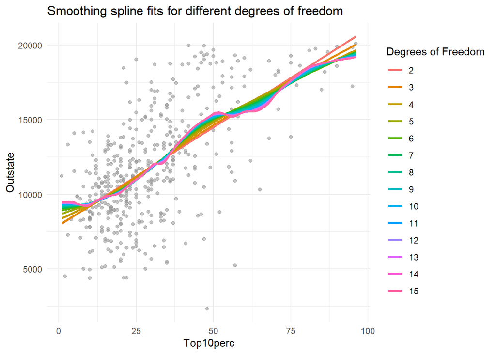

```r
plot1_qa <- ggplot() +
  geom_point(data = df_train,
             aes(x = top10perc, y = outstate),
             color = "grey60", alpha = 0.6) +
  geom_line(data = df_curve_data,
            aes(x = Top10perc, y = Outstate_hat, color = df),
            linewidth = 1) +
  labs(x = "Top10perc",
       y = "Outstate",
       color = "Degrees of Freedom",
       title = "Smoothing spline fits for different degrees of freedom") +
  theme_minimal()

plot1_qa
```

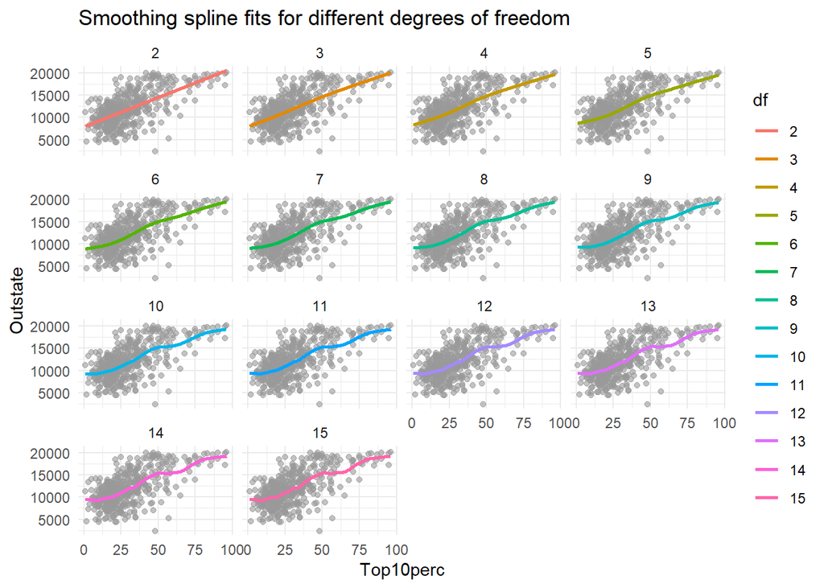

```r
ggsave("plots/2026-03-15_plot1-question1_multi-dfs.png", plot1_qa)
plot2_qa <- ggplot() +
  geom_point(data = df_train,
             aes(x = top10perc, y = outstate),
             color = "grey60", alpha = 0.6) +
  geom_line(data = df_curve_data,
            aes(x = Top10perc, y = Outstate_hat, color = df),
            linewidth = 1) +
  facet_wrap(~ df, ncol = 4) +
  labs(x = "Top10perc",
       y = "Outstate",
       title = "Smoothing spline fits for different degrees of freedom") +
  theme_minimal()

plot2_qa
```

```r
ggsave("plots/2026-03-15_plot2-question1_facets.png", plot2_qa)
```

- As the degrees of freedom increase, the smoothing spline becomes more flexible.
- For very small degrees of freedom (e.g df = 2 or 3), the fitted curve is nearly linear and captures only the overall increasing trend between `Top10perc` and `Outstate`.
- As the degrees of freedom increase (df from f to 8), the curve begins to capture nonlinear patterns in the data, particularly slight curvature in the middle range of `Top10perc`.
- For larger degrees of freedom ($df \ge 10$), the fitted curves become more flexible and show additional local fluctuations, indicating that the model may start fitting noise.
- However, the overall trend remains similar, suggesting that increasing the degrees of freedom beyond a certain point does not substantially change the fitted relationship.

## 2.3 Choose the Best DF

```r
fit_one <- smooth.spline(x = df_train$top10perc, y = df_train$outstate, cv = TRUE)
fit_one$df
```

```
## [1] 4.151115
```

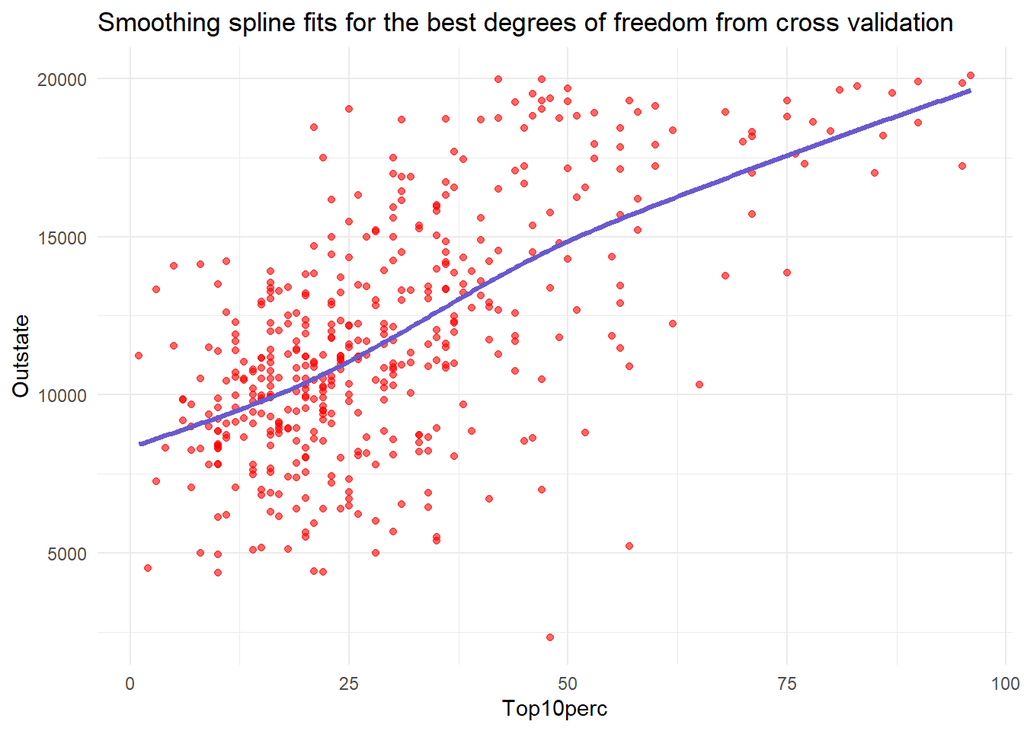

```r
pred_cv <- predict(fit_one, x = vec_x_grid)
df_cv_data <- tibble(
   Top10perc = pred_cv$x,
   Outstate_hat = pred_cv$y,
   df = fit_one$df
)

plot3_qa <- ggplot() +
  geom_point(data = df_train, aes(x = top10perc, y = outstate),
             color = "red", alpha = 0.6) +
  geom_line(data = df_cv_data, aes(x = Top10perc, y = Outstate_hat),
            color = "#6a5acd", linewidth = 1.2) +
  labs(x = "Top10perc",
       y = "Outstate",
       title = "Smoothing spline fits for the best degrees of freedom from cross validation") +
  theme_minimal()

plot3_qa
```

```r
ggsave("plots/2026-03-15_plot3-question1_splines-for-cv.png", plot3_qa)
```

Cross-validation selected an effective degree of freedom of approximately 4.1511149.

# 3 Question b

## 3.1 Fit the MARS Model

```r
df_train2 <- df_train |>
  select(-college)
df_test2  <- df_test  |>
  select(-college)

fit_two_mars <- earth(outstate ~ ., data = df_train2)
summary(fit_two_mars)
```

```
## Call: earth(formula=outstate~., data=df_train2)
##
##                     coefficients
## (Intercept)           15509.7443
## h(apps-1415)              0.4534
## h(1611-accept)           -1.6732
## h(886-enroll)             4.8961
## h(1417-f_undergrad)      -1.7009
## h(f_undergrad-1417)      -0.3296
## h(5600-room_board)       -0.7488
## h(1300-personal)          1.0118
## h(ph_d-84)               99.4099
## h(21-perc_alumni)       -75.5715
## h(15886-expend)          -0.5721
## h(83-grad_rate)         -31.5161
## h(grad_rate-83)         -57.8688
##
## Selected 13 of 21 terms, and 10 of 16 predictors
## Termination condition: RSq changed by less than 0.001 at 21 terms
## Importance: expend, grad_rate, room_board, accept, enroll, apps, ...
## Number of terms at each degree of interaction: 1 12 (additive model)
## GCV 2812814    RSS 1134640767    GRSq 0.7974974    RSq 0.8184764
```

The regression function is:
$$\begin{aligned}
\widehat{\text{outstate}} =\;& 15509.7443
+ 0.4534\,\max(0,\text{apps}-1415)
- 1.6732\,\max(0,1611-\text{accept}) \\
&+ 4.8961\,\max(0,886-\text{enroll})
- 1.7009\,\max(0,1417-\text{f_undergrad})
- 0.3296\,\max(0,\text{f_undergrad}-1417) \\
&- 0.7488\,\max(0,5600-\text{room_board})
+ 1.0118\,\max(0,1300-\text{personal})
+ 99.4099\,\max(0,\text{phd}-84) \\
&- 75.5715\,\max(0,21-\text{perc_alumni})
- 0.5721\,\max(0,15886-\text{expend})
- 31.5161\,\max(0,83-\text{grad_rate}) \\
&- 57.8688\,\max(0,\text{grad_rate}-83).
\end{aligned}$$

## 3.2 Report `expand`

```r
pdp_expend <- partial(
  object = fit_two_mars,
  pred.var = "expend",
  train = df_train2
)

png("plots/2026-03-15_plot4-question2_partial-fig-for-mars.png",
    width = 800, height = 600)

plot4_qb <- plotPartial(pdp_expend,
            xlab = "Expend",
            ylab = "Predicted Outstate",
            main = "Partial Dependence Plot for Expend")

plot4_qb
dev.off()
```

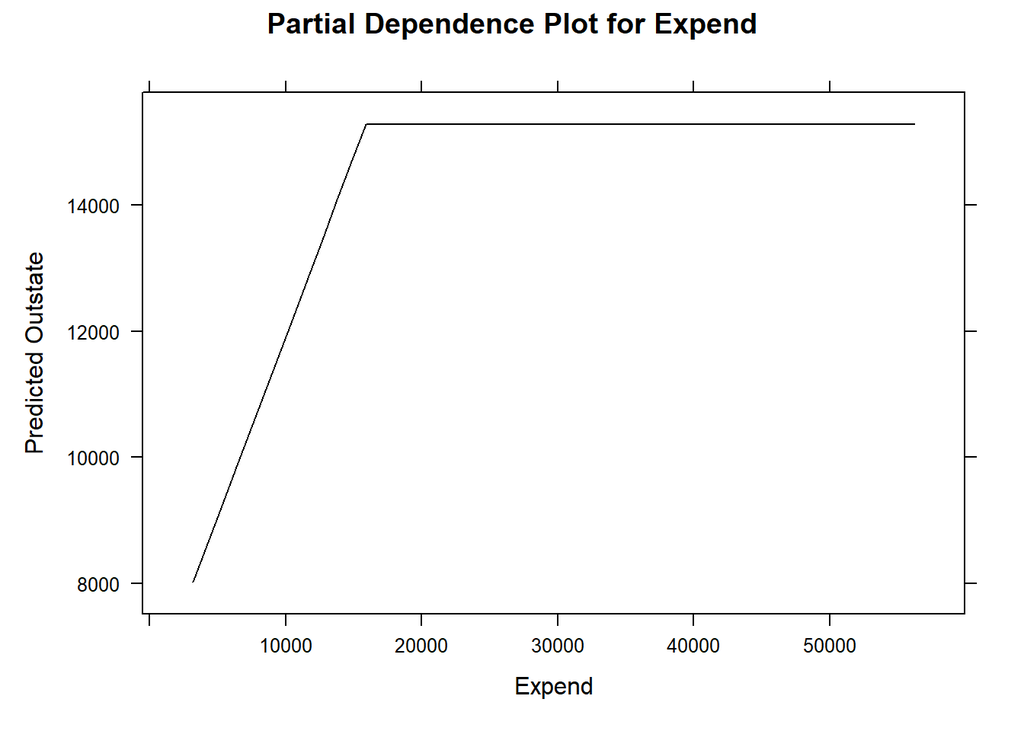

```r
plot4_qb
```

```r
pred_test <- predict(fit_two_mars, newdata = df_test2)

test_mse <- mean((df_test2$outstate - pred_test)^2)
test_mse
```

```
## [1] 3088379
```

Variable `expand` is chosen as the arbitrary predictor, and the test MSE is 3.0883792^{6}.

# 4 Question c

```r
fit_three_gam <- gam(
  outstate ~
    s(expend) +
    s(grad_rate) +
    s(room_board) +
    s(enroll) +
    s(accept) +
    s(apps),
  data = df_train2
)

png("plots/2026-03-15_questionC_GAM_smooth_plots.png",
    width = 1200, height = 800)

plot(fit_three_gam, pages = 1)

dev.off()
```

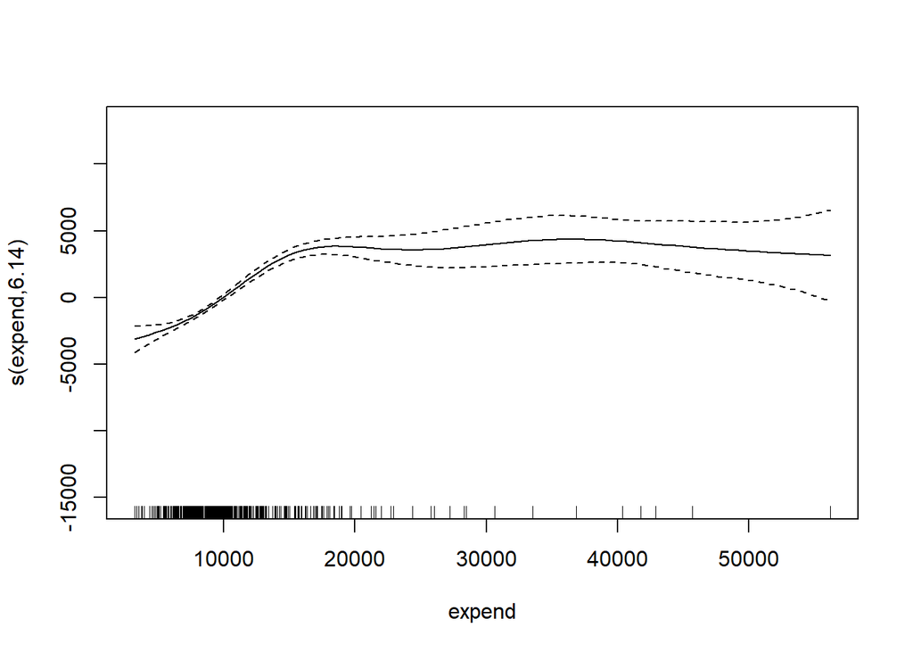

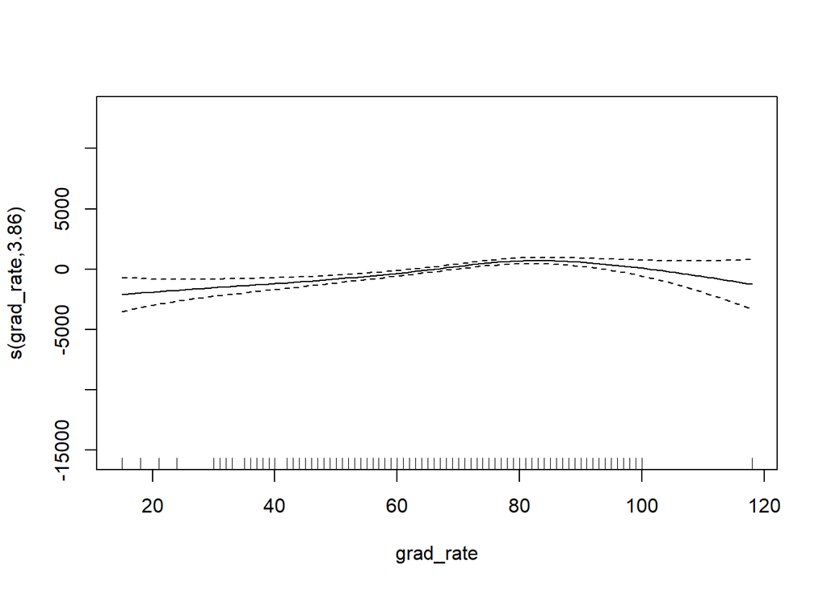

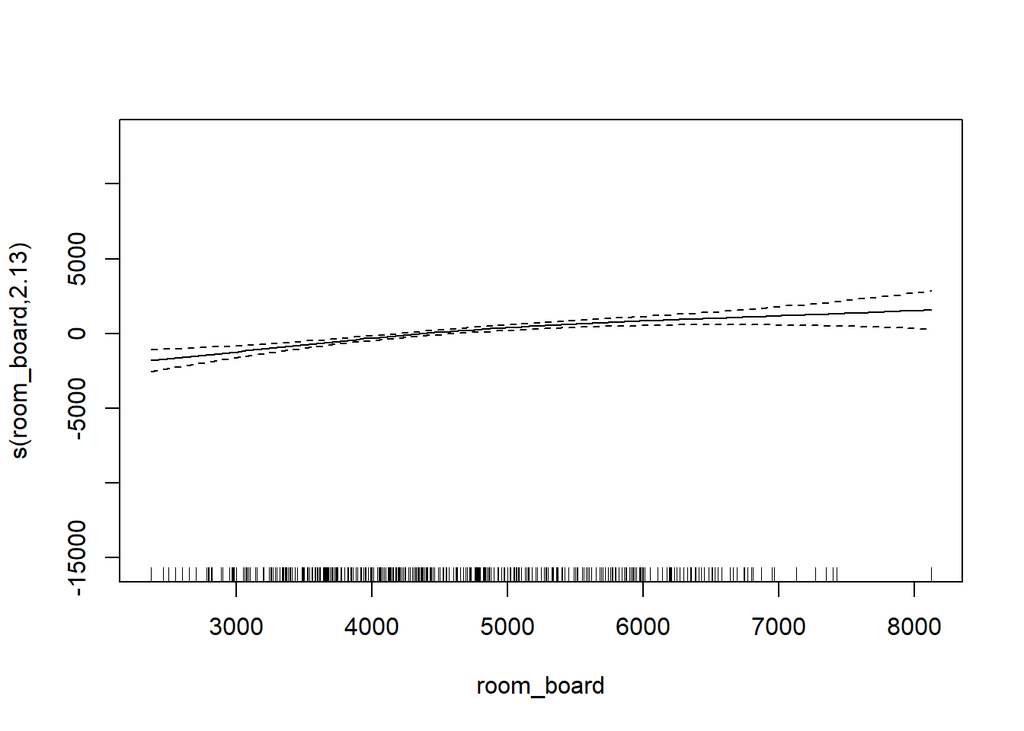

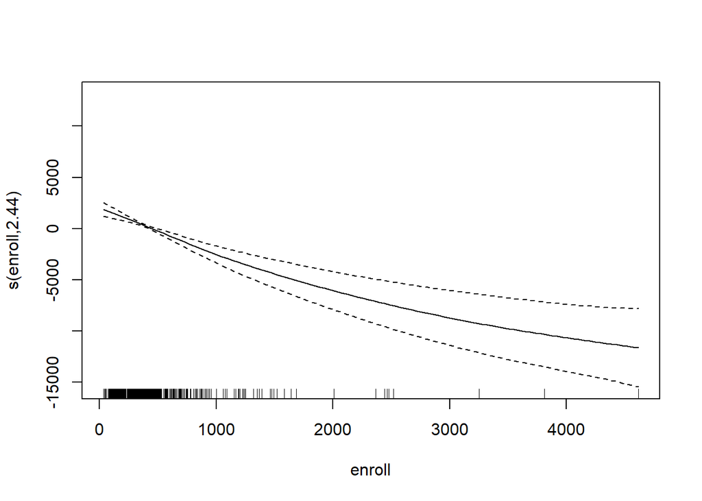

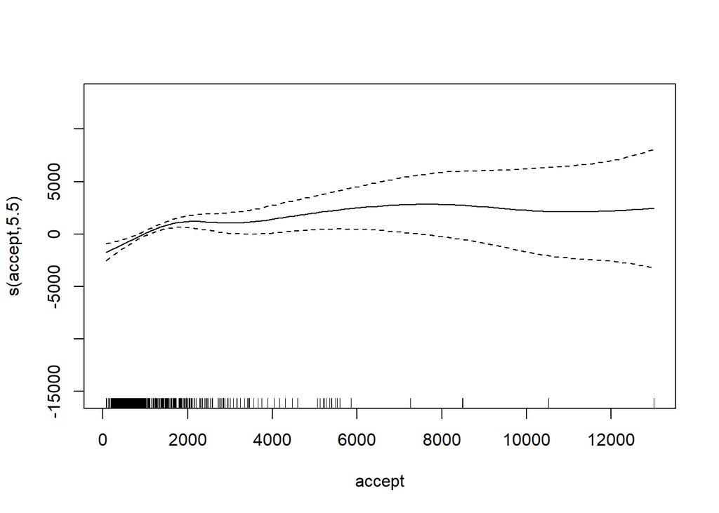

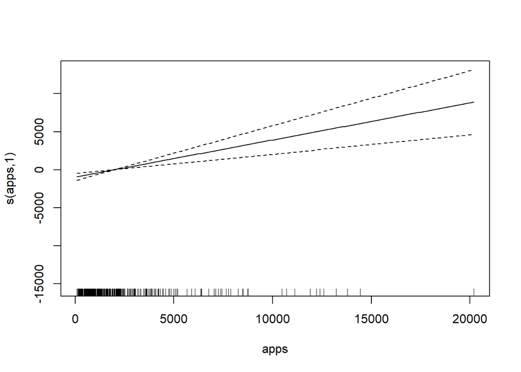

```r
plot(fit_three_gam)
```

- The effect of expenditure per student (expend) is strongly nonlinear. Tuition increases rapidly as expenditure rises but tends to level off at very high levels of expenditure.
- The relationship between graduation rate (grad_rate) and tuition appears relatively weak, with only a slight increase around moderate graduation rates.
- The effect of room and board costs (room_board) is positive and approximately linear, suggesting that institutions with higher housing costs also tend to charge higher tuition.
- The smooth function for enrollment (enroll) shows a clear negative relationship, indicating that larger institutions tend to charge lower out-of-state tuition.
- The number of accepted students (accept) shows a mild positive association with tuition, although the uncertainty increases for larger values.
- Finally, the number of applications (apps) also has a positive effect, suggesting that schools receiving more applications tend to have higher tuition levels.

```r
pred_gam <- predict(fit_three_gam, newdata = df_test2)
mse_gam <- mean((df_test2$outstate - pred_gam)^2)
mse_gam
```

```
## [1] 3318481
```

The test mean squared error (MSE) of the GAM model is 3.3184812^{6}.

# 5 Question d

```r
fit_four_lm <- lm(outstate ~ expend + grad_rate + room_board + enroll + accept + apps,
  data = df_train2)
pred_lm <- predict(fit_four_lm, newdata = df_test2)
mse_lm <- mean((df_test2$outstate - pred_lm)^2)
mse_lm
```

```
## [1] 4974232
```